# Hintzman 1986

Matt Crump

August 30, 2016

# 1986 Simulation 1: Abstraction

Load libraries

Each memory trace and each probe was a 23 unit vector.

Units 1-10 represented the category name, and 11-23 represented the stimulus pattern. Each unit had a .5 probability of being assigned a +1 (activated unit) or a -1 (inhibited unit).

Three category names and prototypes were used in the simulations.

## Construct three category names and prototype patterns

Create a 3 (rows) x 23 (columns) matrix, with each unit assigned 1 or -1 with p=.5

Use the following functions

- runif(n,min,max) - samples n times from a uniform distribution between min and max
- sign() - converts digits to 1 or -1
- matrix(vector,nrow,ncol) converts vector to a matrix

```r
categories_prototypes <- matrix(sign(runif(3*23,-1,1)),nrow=3,ncol=23)
```

## Create distortions of the prototype pattern

Distortions of each prototype pattern (exemplars of a category) were generated by randomly selecting two (low distortion) or four (high distortion) units from each prototype and flipping their sign (multiply by -1).

```r
# create empty matrix with room for 3, 6, and 9 exemplars from each category
distorted_exemplars <- matrix(nrow = 18, ncol = 23)
i <- 0
number_of_exemplars <- c(3, 6, 9)
for (m in 1:3) {
  for (mm in 1:number_of_exemplars[m]){
    i <- i + 1
    #create distortion vector
    distortion_vector <- rep(1, 23)
    distortion_vector[sample(seq(11, 23), 2)] <- -1
    # multiply distortion and prototype and save in matrix
    distorted_exemplars[i, ] <- distortion_vector * categories_prototypes[m, ]
  }
}
```

## Function to get an echo from a memory

MINERVA compares a probe pattern to all stored exemplars in memory. Each exemplar is weighted by it’s similarity to the probe. The weighted vectors are summed into the echo.

```r
# probe is the input vector, mem is the matrix of exemplars
# requires LSA package for cosine
# (may not be exactly the same similarity function as Hintzman 1986)

get_echo <- function(probe, mem) {
    # compute similarities between probe and memories
    sim_vals <- c()
    for (m in 1:dim(mem)[1]) {
        sim_vals[m] <- cosine(probe, mem[m, ])
    }
    # Weight memories by similarity
    weighted_memory <- mem * (sim_vals^3)
    summed_echo <- colSums(weighted_memory)
    return(summed_echo)
}
```

## Probe with Category Name

```r
# probe memory, return echo, correlate echo against original prototype
current_probe <- c(categories_prototypes[1, 1:10], rep(0, 13))
echo <- get_echo(current_probe, distorted_exemplars)
cor(echo[11:23], categories_prototypes[1, 11:23])
```

```
## [1] 0.8834737
```

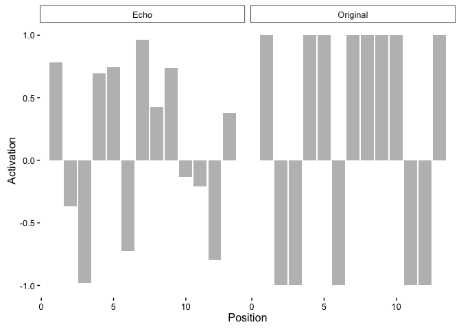

```r
# plot the echo and the original
activations <- c(categories_prototypes[1,11:23], echo[11:23])
cue <- rep(c("Original", "Echo"), each=13)
neuron_unit <- rep(seq(1:13) ,2)
dframe <- data.frame(cue, neuron_unit, activations)

ggplot(data=dframe, aes(y=activations, x=neuron_unit))+
  geom_bar(stat="identity", position = position_dodge(), fill = "gray") +
  theme_classic(base_size = 12) +
  ylab("Activation") +
  xlab("Position") +
  facet_wrap(~cue)
```

## Running multiple simulated Subjects

Each simulated subject is shown 3, 6 and 9 exemplars across three categories. Each of the category names is probed, and the retrieved echo pattern is compared to the prototype pattern. The correlation between the retrieved pattern and the original prototype should increase with the number of exemplars in memory. Category 1 has 3 exemplars, Category 2 has 6 exemplars, and Category 3 has 9 exemplars. Hintzman ran 20 simulated subjects.

```r
# loop for each subject
simulation_df <- data.frame()
for(subs in 1:20){

  # original category and prototype patterns
  categories_prototypes <- matrix(sign(runif(3*23, -1, 1)), nrow=3, ncol=23)

  # 3, 6, and 9 distortions
  distorted_exemplars <- matrix(nrow = 18, ncol = 23)
  i <- 0
  number_of_exemplars <- c(3, 6, 9)
  for (m in 1:3) {
    for (mm in 1:number_of_exemplars[m]){
      i <- i + 1
      #create distortion vector
      distortion_vector <- rep(1, 23)
      distortion_vector[sample(seq(11, 23), 2)] <- -1
      # multiply distortion and prototype and save in matrix
      distorted_exemplars[i, ] <- distortion_vector * categories_prototypes[m, ]
    }
  }

  #test each category label
  save_correlation <- c()
  for (category_label in 1:3){
    current_probe <- c(categories_prototypes[category_label, 1:10], rep(0, 13))
    echo <- get_echo(current_probe, distorted_exemplars)
    save_correlation <- c(save_correlation,
                          cor(echo[11:23], categories_prototypes[category_label, 11:23]))
  }

  store_data <- data.frame(subject = rep(subs, 3),
                           category = seq(1, 3),
                           correlation = save_correlation)

  simulation_df <- rbind(simulation_df, store_data)
}

# show the data in a table
summary_df <- ddply(simulation_df,.(category),summarise, cor=mean(correlation), se=stde(correlation))
kable(xtable(summary_df),format="markdown")
```

| category | cor | se |
| --- | --- | --- |
| 1 | 0.7940071 | 0.0396063 |
| 2 | 0.9019769 | 0.0076728 |
| 3 | 0.9328775 | 0.0070201 |

# Ambiguous Recall Problem

Same simulation as above except that memory is probed with the original prototype patterns to see whether MINERVA can retrieve the correct category names. The previous simulation used low distortion (2 units different) exemplars, the present simulation uses high distortion exemplars (4 units different).

```r
# loop for each subject
simulation_df <- data.frame()
for(subs in 1:20){

  # original category and prototype patterns
  categories_prototypes <- matrix(sign(runif(3*23, -1, 1)), nrow=3, ncol=23)

  # 3, 6, and 9 distortions
  distorted_exemplars <- matrix(nrow = 18, ncol = 23)
  i <- 0
  number_of_exemplars <- c(3, 6, 9)
  for (m in 1:3) {
    for (mm in 1:number_of_exemplars[m]){
      i <- i + 1
      #create distortion vector
      distortion_vector <- rep(1, 23)
      distortion_vector[sample(seq(11, 23), 4)] <- -1
      # multiply distortion and prototype and save in matrix
      distorted_exemplars[i, ] <- distortion_vector * categories_prototypes[m, ]
    }
  }

  #test each prototype pattern
  save_correlation <- c()
  for (category_label in 1:3){
    current_probe <- c(rep(0, 10), categories_prototypes[category_label, 11:23])
    echo <- get_echo(current_probe, distorted_exemplars)
    save_correlation <- c(save_correlation,
                          cor(echo[1:10], categories_prototypes[category_label, 1:10]))
  }

  store_data <- data.frame(subject = rep(subs, 3),
                           category = seq(1, 3),
                           correlation = save_correlation)

  simulation_df <- rbind(simulation_df, store_data)
}

# show the data in a table
summary_df <- ddply(simulation_df,.(category),summarise, cor=mean(correlation), se=stde(correlation))
kable(xtable(summary_df),format="markdown")
```

| category | cor | se |
| --- | --- | --- |
| 1 | 0.5756939 | 0.0574359 |
| 2 | 0.8735401 | 0.0393699 |
| 3 | 0.9312723 | 0.0225852 |

## Cleaning up the echo

In the ambiguous recall example, probing memory with the prototype pattern resulted in the varying degress of success in clearly retrieving the associated category label. Hintzman showed that MINERVA can bootstrap itself out of this problem through an iterative retrieval process that allows the clarity of the category features to be improved across successive retrieval iterations.

The iterative retrieval process involves the following steps.

1. Retrieve an echo
2. Normalize the echo (divide by the max all units in the vector)
3. Submit the normalized echo as probe to memory
4. Retrieve new echo, normalize it, submit it back to memory etc.

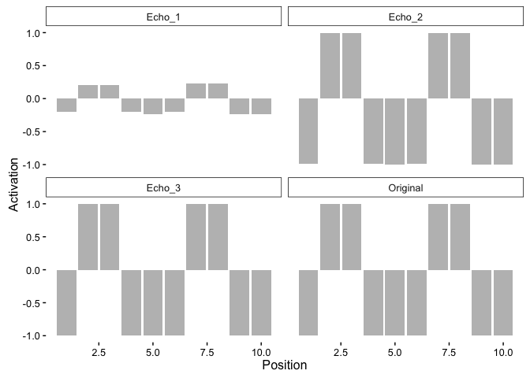

```r
# function for iterative retrieval
normalize_vector <- function(vector_input){
  return(vector_input/max(abs(vector_input)))
}

iterative_retrieval <- function(probe, mem, iterations) {
  normalized_echo <- normalize_vector(get_echo(probe, mem))
  for (i in 1:iterations) {
   normalized_echo <- normalize_vector(get_echo(normalized_echo, mem))
  }
  return(normalized_echo)
}

# plot results of iterative retrieval
current_probe <- c(rep(0, 10), categories_prototypes[3, 11:23])
echo <- get_echo(current_probe, distorted_exemplars)
echo1 <- iterative_retrieval(current_probe, distorted_exemplars, 1)
echo2 <- iterative_retrieval(current_probe, distorted_exemplars, 2)

activations <- c(categories_prototypes[3,1:10],
                 echo[1:10],
                 echo1[1:10],
                 echo2[1:10])
cue <- rep(c("Original", "Echo_1","Echo_2","Echo_3"), each=10)
neuron_unit <- rep(seq(1:10) ,4)
dframe <- data.frame(cue, neuron_unit, activations)

ggplot(data=dframe, aes(y=activations, x=neuron_unit))+
  geom_bar(stat="identity", position = position_dodge(), fill = "gray") +
  theme_classic(base_size = 12) +
  ylab("Activation") +
  xlab("Position") +
  facet_wrap(~cue)
```

# Basic Findings

Directly from the paper:

To evaluate the model’s performance on the schema-abstraction task, 3, 6, and 9 high-level distortions of three prototypes were generated, respectively, and each was paired with the appropriate category name and encoded in SM as described earlier, for a total of 18 SM traces.

Classification testing was carried out using one probe per category representing each of the following conditions: (a) an old exemplar (one that was originally stored in SM), (b) the category prototype, (c) a new low-level distortion of the prototype, (d) a new high-level distortion of the prototype, and (e) a random pattern.

A forgetting cycle followed, during which each feature stored in SM–that is, each T(i, j)–either remained the same with Pr = .25 or reverted to zero with Pr = .75. Then testing was done again in the same way. Three hundred subjects were simulated by repeating the entire procedure, from the generation of new prototypes and names through the final test, 300 times.

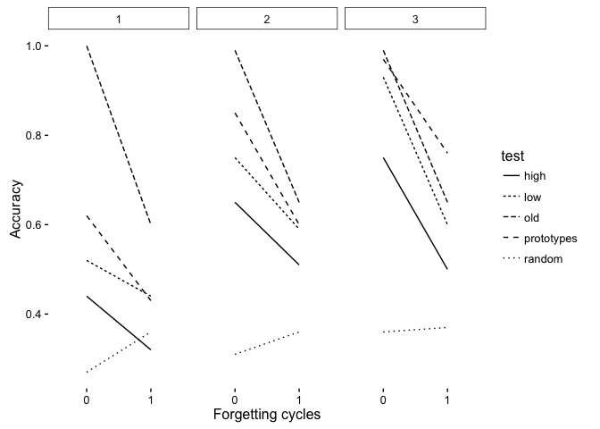

```r
# loop for each subject
simulation_df <- data.frame()
for(subs in 1:100){

  # original category and prototype patterns
  categories_prototypes <- matrix(sign(runif(3*23, -1, 1)), nrow=3, ncol=23)

  # 3, 6, and 9 high level distortions
  distorted_exemplars <- matrix(nrow = 18, ncol = 23)
  i <- 0
  number_of_exemplars <- c(3, 6, 9)
  for (m in 1:3) {
    for (mm in 1:number_of_exemplars[m]){
      i <- i + 1
      #create distortion vector
      distortion_vector <- rep(1, 23)
      distortion_vector[sample(seq(11, 23), 4)] <- -1
      # multiply distortion and prototype and save in matrix
      distorted_exemplars[i, ] <- distortion_vector * categories_prototypes[m, ]
    }
  }

  # new low level distortions for test
  low_test_distorted_exemplars <- matrix(nrow = 3, ncol = 23)
  i <- 0
  number_of_exemplars <- c(1, 1, 1)
  for (m in 1:3) {
    for (mm in 1:number_of_exemplars[m]){
      i <- i + 1
      #create distortion vector
      distortion_vector <- rep(1, 23)
      distortion_vector[sample(seq(11, 23), 2)] <- -1
      # multiply distortion and prototype and save in matrix
      low_test_distorted_exemplars[i, ] <- distortion_vector * categories_prototypes[m, ]
    }
  }

  # new high level distortions for test
  high_test_distorted_exemplars <- matrix(nrow = 3, ncol = 23)
  i <- 0
  number_of_exemplars <- c(1, 1, 1)
  for (m in 1:3) {
    for (mm in 1:number_of_exemplars[m]){
      i <- i + 1
      #create distortion vector
      distortion_vector <- rep(1, 23)
      distortion_vector[sample(seq(11, 23), 4)] <- -1
      # multiply distortion and prototype and save in matrix
      high_test_distorted_exemplars[i, ] <- distortion_vector * categories_prototypes[m, ]
    }
  }

  # new random vectors for test
  random_test <- matrix(sign(runif(3*23, -1, 1)), nrow=3, ncol=23)

  # combine all test vectors into a single matrix of test itemts
  test_matrix <- matrix()
  test_matrix <- rbind(distorted_exemplars[1,],
                       distorted_exemplars[4,],
                       distorted_exemplars[10,],
                       categories_prototypes,
                       low_test_distorted_exemplars,
                       high_test_distorted_exemplars,
                       random_test)
  correct_category <- rep(seq(1,3),5)

  #test each pattern: 0 forgetting
  save_answer <- c()
  for (test_item in 1:15){
    current_probe <- c(rep(0, 10), test_matrix[test_item, 11:23])
    echo <- get_echo(current_probe, distorted_exemplars)
    category_correlations <- cor(echo[1:10], t(categories_prototypes[, 1:10]))
    choice <- which.max(category_correlations)
    save_answer <- c(save_answer, choice)
  }

  store_data <- data.frame(subject = rep(subs, 15),
                           forgetting = rep(0,15),
                           test = c(rep("old",3),
                                    rep("prototypes",3),
                                    rep("low",3),
                                    rep("high",3),
                                    rep("random",3)),
                           category = correct_category,
                           choice = save_answer)

  simulation_df <- rbind(simulation_df, store_data)

  #test each pattern: 1 forgetting
  forgetting_matrix <- matrix(rbinom(18*23, 1, .25), nrow=18, ncol=23)*distorted_exemplars
  forgetting_matrix <- forgetting_matrix + matrix(runif(18*23, -.05, .05),nrow=18, ncol=23)
  save_answer <- c()
  for (test_item in 1:15){
    current_probe <- c(rep(0, 10), test_matrix[test_item, 11:23])
    echo <- get_echo(current_probe, forgetting_matrix)
    category_correlations <- cor(echo[1:10], t(categories_prototypes[, 1:10]))
    choice <- which.max(category_correlations)
    save_answer <- c(save_answer, choice)
  }

  store_data <- data.frame(subject = rep(subs, 15),
                           forgetting = rep(1,15),
                           test = c(rep("old",3),
                                    rep("prototypes",3),
                                    rep("low",3),
                                    rep("high",3),
                                    rep("random",3)),
                           category = correct_category,
                           choice = save_answer)

  simulation_df <- rbind(simulation_df, store_data)
}

# plot the data
simulation_df <- cbind(simulation_df, accuracy = simulation_df$category == simulation_df$choice)
simulation_df$forgetting <- factor(simulation_df$forgetting)
simulation_df$category <- factor(simulation_df$category)
summary_df <- ddply(simulation_df,.(test, category, forgetting), summarise, acc = mean(accuracy))

ggplot(data = summary_df, aes(y = acc, x = forgetting, group = test))+
  geom_line(aes(linetype = test)) +
  theme_classic(base_size = 12) +
  ylab("Accuracy") +
  xlab("Forgetting cycles") +
  facet_wrap(~category)
```